# Proyecto final integrador · Fase 4

## Factores sociodemográficos y su asociación con factores de riesgo cardiovascular, utilizando la Encuesta Nacional de Salud (ENS) 2016-2017 de Chile.

**MCDI500 · Programación para la Ciencia de Datos · Grupo 4**

Integrantes: Felipe Díaz Toro, Ninoska Yévenes Hernández, Guillermo Subiabre Chacón, Pablo Ríos Passteni Docente: Omar Salinas

## Parte 0 · Entorno y reproducibilidad

```python
import sys
import numpy as np
import pandas as pd
import matplotlib.pyplot as plt
import seaborn as sns

sns.set_theme(style="whitegrid", palette="deep")

print("REGISTRO DEL ENTORNO")
print("=" * 58)
print(f"  Python      : {sys.version.split()[0]}")
print(f"  NumPy       : {np.__version__}")
print(f"  pandas      : {pd.__version__}")
print(f"  Matplotlib  : {plt.matplotlib.__version__}")
print(f"  seaborn     : {sns.__version__}")
print(f"  Entorno virtual activo: {sys.prefix != sys.base_prefix}")
```

```
REGISTRO DEL ENTORNO
==========================================================
  Python      : 3.13.7
  NumPy       : 2.5.3
  pandas      : 3.0.5
  Matplotlib  : 3.11.1
  seaborn     : 0.13.2
  Entorno virtual activo: True
```

# I. Fase 1 · El problema y los objetivos

## 1.1 Contexto y problema

Las enfermedades cardiovasculares son la principal causa de muerte en Chile y en el mundo. Según la Encuesta Nacional de Salud (ENS) 2016-2017 del Ministerio de Salud, la prevalencia nacional de hipertensión arterial alcanza 27,6% y la de sospecha de diabetes mellitus 12,3% en personas de 15 años y más (MINSAL, 2017). Estas cifras agregadas no informan cómo se distribuye el riesgo al interior de la población.

**Problema.** Se dispone de registros individuales de la ENS 2016-2017, pero no de una caracterización de cómo el perfil sociodemográfico de las personas encuestadas se asocia con los principales indicadores de riesgo cardiovascular disponibles en la encuesta.

## 1.2 Pregunta de investigación

> ¿Cómo se relacionan las condiciones sociodemográficas (edad, sexo, nivel educacional, ingreso del hogar y zona de residencia) con la presencia de hipertensión arterial, diabetes, colesterol alto, índice de masa corporal y nivel de actividad física en los participantes de la ENS 2016-2017?

## 1.3 Objetivo general

> Caracterizar la relación entre las condiciones sociodemográficas de los participantes (edad, sexo, nivel educacional, ingreso del hogar y zona de residencia) y la presencia de hipertensión arterial, diabetes, colesterol alto, un índice de masa corporal elevado y un nivel insuficiente de actividad física en la ENS 2016-2017

## 1.4 Objetivos específicos

1. Comparar la prevalencia de hipertensión arterial entre los distintos grupos etarios.
2. Describir cómo varía la prevalencia de diabetes según el grupo etario y la zona de residencia.
3. Analizar la relación entre el nivel educacional y la presencia de colesterol alto.
4. Examinar la asociación entre el índice de masa corporal y el nivel de actividad física.
5. Evaluar si la relación entre edad e índice de masa corporal, en presencia de hipertensión, se mantiene al estratificar por sexo.

## 1.5 Alcance, restricciones y supuestos

Son tres categorías distintas y conviene no mezclarlas.

**Alcance.** El análisis es descriptivo y exploratorio, y se limita al conjunto de encuestados de la ENS 2016-2017 disponible tras el filtro de Fase 1-2. No incluye modelamiento predictivo ni pruebas de hipótesis formales; las asociaciones que se presentan son descriptivas, no causales.

**Restricciones.** La ENS tiene diseño muestral complejo (conglomerados y estratos). En este trabajo, las tasas y promedios que se citan como cifra en el texto se ponderan por el factor de expansión `Fexp_F1F2p_Corr`, para que sean comparables con las cifras oficiales de MINSAL (por ejemplo, el 27,6% de HTA citado en la introducción). Las distribuciones que se muestran directamente en los diagramas de caja y de dispersión (Figuras 2 y 3, y la exploración del Objetivo 3) se presentan sin ponderar, porque las librerías utilizadas no calculan cuartiles ponderados de forma nativa, y no corresponde ponderar observaciones individuales; en esos casos se reporta el promedio ponderado como referencia complementaria, declarado junto a cada figura. Sin embargo, no se estima varianza ni intervalos de confianza con métodos de diseño muestral (conglomerados/estratos), ya que eso requiere herramientas como el paquete `survey` de R o `samplics` de Python, fuera del alcance de este curso; por lo tanto, las diferencias que se describen son puntos estimados, no diferencias estadísticamente probadas. La variable `as27` (ingreso del hogar) tiene un 18% de valores nulos, imputados según lo documentado en Fase 2-3. El índice de masa corporal y otras variables clínicas se basan en autorreporte o medición en un único momento, sin seguimiento longitudinal.

**Supuestos.** Cada fila corresponde a una persona distinta. Las variables categóricas se codificaron según el libro de códigos oficial de la ENS. Los grupos etarios se construyen con cortes definidos por el equipo y declarados en la Parte IV.

# II. Fase 2 · El conjunto preparado

La Fase 2 no se repite acá: se carga su resultado y se documentan las decisiones que lo produjeron.

## 2.1 Decisiones de preparación y su justificación

| Decisión | Alternativa descartada | Razón |
| --- | --- | --- |
| Conservar los registros sin ingreso (`as27`/`as28`), marcados con bandera | Eliminar las filas | Los faltantes no son aleatorios |
| Imputar `as27` por mediana dentro de su propio tramo (`as28`) | Imputar con la mediana global | Preserva la estructura por tramo de ingreso |
| Codificar Sexo, Zona, diabetes y colesterol con one-hot | Codificación ordinal | Son categorías nominales, sin orden |
| Escalar Edad, IMC e ingreso con media y desviación | Dejar las unidades originales | Requerido por Fase 3 |
| Reclasificar GPAQ de nominal a ordinal | Tratarla como nominal | Bajo < Moderado < Alto tiene orden |

**Consecuencia para la Fase 4.** Las dos últimas decisiones dejan el conjunto ilegible para graficar (edad e IMC centrados en cero, sexo convertido en columnas de ceros y unos). La Parte IV resuelve esto.

## 2.2 Carga del conjunto de la Fase 2

```python
import sys
from pathlib import Path

RAIZ = Path.cwd().parent.parent  # ajusta si tu notebook no está en F4/notebooks/
sys.path.insert(0, str(RAIZ))

from src.carga import leer_archivo

datos = leer_archivo(str(RAIZ / "data" / "processed" / "ens_variables_f1f2.xlsx"))
print(f"Conjunto de origen (F1-F2): {datos.shape[0]} filas x {datos.shape[1]} columnas")
datos.head(3)
```

```
Conjunto de origen (F1-F2): 5520 filas x 16 columnas
```

|  | IdEncuesta | FechaInicioF1 | Edad | Sexo | Zona | HTA | di3 | dis2 | IMC | anos_estudio_MINSAL_1 | GPAQ | as27 | as28 | Fexp_F1F2p_Corr | Conglomerado | Estrato |
| --- | --- | --- | --- | --- | --- | --- | --- | --- | --- | --- | --- | --- | --- | --- | --- | --- |
| 0 | 20008 | 2016-11-27 15:10:40 | 25 | 2 | 1 | 0.0 | 2 | 3 | 23.198208 | 15.0 | 3.0 | 200000.0 | 3 | 52.307503 | 13101101 | 131 |
| 1 | 20011 | 2016-11-26 15:52:49 | 20 | 2 | 1 | 0.0 | 2 | 3 | 26.203983 | 14.0 | 3.0 | NaN | -9999 | 250.753357 | 13101102 | 131 |
| 2 | 20012 | 2016-11-20 13:16:39 | 85 | 2 | 1 | 1.0 | 2 | 2 | 23.732346 | 15.0 | 1.0 | 1300000.0 | 10 | 133.128342 | 13101102 | 131 |

# III. Fase 3 · El núcleo algorítmico

Se integran las clases de `src/` que ya construyeron y se verifica que el pipeline reproduce exactamente el resultado oficial de la Fase 2.

## 3.1 El pipeline completo

```python
from src.imputadores import MarcadorNoRespuesta, EliminadorFilasNulas, ImputadorFlexible
from src.imputadores import PorMediana, PorMedianaDeTramo, PorModa
from src.transformadores import CodificadorOneHot, EscaladorEstandar, EliminadorColumna, ConvertidorEntero
from src.pipeline import Pipeline

variables_categoricas = ["Sexo", "Zona", "di3", "dis2"]
variables_numericas = ["Edad", "IMC", "as27"]

pasos_limpieza = [
    MarcadorNoRespuesta("as28"),
    EliminadorFilasNulas("HTA"),
    ImputadorFlexible("IMC", PorMediana()),
    ImputadorFlexible("anos_estudio_MINSAL_1", PorMediana()),
    ImputadorFlexible("as27", PorMedianaDeTramo("as28")),
    ImputadorFlexible("GPAQ", PorModa()),
]

pasos_integracion = (
    [EliminadorColumna(col) for col in ["IdEncuesta", "FechaInicioF1"]]
    + [ConvertidorEntero(col) for col in ["HTA", "GPAQ"]]
    + [CodificadorOneHot(col) for col in variables_categoricas]
    + [EscaladorEstandar(col) for col in variables_numericas]
)

pipeline_completo = Pipeline(pasos_limpieza + pasos_integracion)
df_transformado = pipeline_completo.ajustar_transformar(datos)

print(f"Dimensiones iniciales : {datos.shape}")
print(f"Dimensiones finales   : {df_transformado.shape}")
```

```
Dimensiones iniciales : (5520, 16)
Dimensiones finales   : (5511, 23)
```

## 3.2 Eficiencia computacional

Además de validar el pipeline, se comprueba brevemente el costo computacional de los transformadores propios frente a una implementación de referencia de scikit-learn/pandas. El análisis completo (variación de tamaño de muestra, medición de memoria con `tracemalloc`, y evaluación de complejidad) se realizó en Fase 3 y está documentado en `F3/notebooks/S2_F3_NucleoAlgoritmico_Eficiencia_POO.ipynb`. Aquí se replica la comparación de tiempos sobre el conjunto real de este proyecto (5.511 filas), como evidencia directa dentro del notebook consolidado.

```python
from src.medicion import medir_tiempo_timeit
from sklearn.preprocessing import StandardScaler

def escalar_propio(df, columna):
    return EscaladorEstandar(columna).ajustar_transformar(df[[columna]].copy())

def escalar_sklearn(df, columna):
    resultado = df[[columna]].copy()
    resultado[columna] = StandardScaler().fit_transform(resultado[[columna]])
    return resultado

tiempo_propio = medir_tiempo_timeit(escalar_propio, df_transformado, "Edad")
tiempo_sklearn = medir_tiempo_timeit(escalar_sklearn, df_transformado, "Edad")

pd.DataFrame([
    {"implementacion": "EscaladorEstandar (propio)", "tiempo_s": tiempo_propio},
    {"implementacion": "StandardScaler (sklearn)", "tiempo_s": tiempo_sklearn},
])
```

|  | implementacion | tiempo_s |
| --- | --- | --- |
| 0 | EscaladorEstandar (propio) | 0.000220 |
| 1 | StandardScaler (sklearn) | 0.000663 |

## 3.3 Verificación contra el resultado oficial de la Fase 2

```python
from src.validador import verificar_contra_fase2

RUTA_PROCESADO = RAIZ / "data" / "processed" / "ens_procesado.csv"

pipeline_verificacion = Pipeline(pasos_limpieza + pasos_integracion)
coincide = verificar_contra_fase2(
    pipeline_verificacion,
    datos,
    RUTA_PROCESADO,
    verificar_tipos=True,
)
assert coincide, "El pipeline no reproduce el resultado oficial de la Fase 2"
print("Verificado: el pipeline reproduce exactamente ens_procesado.csv")
```

```
[OK] El resultado coincide con la referencia: 5511 filas x 23 columnas comparadas
Verificado: el pipeline reproduce exactamente ens_procesado.csv
```

## 3.4 Validación técnica (59 pruebas)

Casos normal, límite y excepción, definidos en `tests/casos_por_clase.py`, ejecutados directamente acá.

```python
from tests.casos_por_clase import ejecutar_pruebas

reporte = ejecutar_pruebas()
print(reporte.to_string(index=False))
```

```
59 pruebas: 59 OK, 0 con problemas
               clase escenario                                                                              prueba estado                                                                                                             detalle
       Transformador    normal        Ajustar devuelve el mismo paso, guarda lo aprendido y transformar lo aplica.     OK
       Transformador    limite              parametros entrega una copia: modificarla no altera el estado interno.     OK
       Transformador    limite         transformar trabaja sobre una copia y deja intacto el DataFrame de entrada.     OK
       Transformador excepcion                                    transformar antes de ajustar lanza RuntimeError.     OK                                                           RuntimeError: _PasoDoblador(x): falta llamar a ajustar().
       Transformador excepcion                               Ajustar con una columna que no existe lanza KeyError.     OK                                                     KeyError: "_PasoDoblador(otra): 'otra' no está en el conjunto."
       Transformador excepcion             La clase base no se usa sola: sin aprender() lanza NotImplementedError.     OK                                                        NotImplementedError: Transformador no implementa aprender().
       Transformador excepcion                      parametros no se puede reasignar desde fuera (AttributeError).     OK                                       AttributeError: property 'parametros' of '_PasoDoblador' object has no setter
 MarcadorNoRespuesta    normal                   Pasa los códigos -8888 y -9999 a nulo y anota quién no respondió.     OK
 MarcadorNoRespuesta    limite            Sin códigos presentes no cambia ningún valor y la bandera queda en cero.     OK
 MarcadorNoRespuesta    limite                      Un nulo que ya venía en los datos no cuenta como no respuesta.     OK
 MarcadorNoRespuesta excepcion                                           Una columna que no existe lanza KeyError.     OK                                               KeyError: "MarcadorNoRespuesta(otra): 'otra' no está en el conjunto."
EliminadorFilasNulas    normal                        Quita las filas con nulo en la columna y renumera el índice.     OK
EliminadorFilasNulas    limite                                  Sin nulos en la columna devuelve los mismos datos.     OK
EliminadorFilasNulas    limite             Si todas las filas son nulas queda un DataFrame vacío con sus columnas.     OK
EliminadorFilasNulas    limite                     Los nulos de otras columnas no provocan que se elimine la fila.     OK
EliminadorFilasNulas excepcion                                           Una columna que no existe lanza KeyError.     OK                                              KeyError: "EliminadorFilasNulas(otra): 'otra' no está en el conjunto."
            PorMedia    normal                              Rellena los nulos con la media de los datos presentes.     OK
            PorMedia    limite                                     Con un único dato válido, la media es ese dato.     OK
            PorMedia excepcion                                       Una columna sin ningún dato lanza ValueError.     OK                                                              ValueError: 'x' no tiene datos para calcular la media.
          PorMediana    normal                            Rellena los nulos con la mediana de los datos presentes.     OK
          PorMediana    limite          Con cantidad par de datos, la mediana es el promedio de los dos centrales.     OK
          PorMediana excepcion                                       Una columna sin ningún dato lanza ValueError.     OK                                                            ValueError: 'x' no tiene datos para calcular la mediana.
             PorModa    normal                                       Rellena los nulos con el valor más frecuente.     OK
             PorModa    limite               Con empate entre valores, se elige el menor (igual que en la Fase 2).     OK
```

[output cut: 35 more lines]

# IV. Fase 4 · Conjunto interpretable para visualizar

`df_transformado` tiene la edad e IMC centrados en cero y las categóricas en one-hot — correcto para el análisis, ilegible para graficar. La solución: capturar el dato en el punto del pipeline donde ya está limpio pero todavía no se codifica ni escala, justo antes de `pasos_integracion`. Se reutilizan las mismas clases, sin duplicar lógica de limpieza.

## 4.1 df_visual

```python
pipeline_limpieza = Pipeline(pasos_limpieza)
df_visual = pipeline_limpieza.ajustar_transformar(datos)

print(f"df_visual: {df_visual.shape[0]} filas x {df_visual.shape[1]} columnas")
print(f"  Edad en anios : {df_visual['Edad'].min():.0f} a {df_visual['Edad'].max():.0f}")
print(f"  IMC           : {df_visual['IMC'].min():.1f} a {df_visual['IMC'].max():.1f}")
```

```
df_visual: 5511 filas x 18 columnas
  Edad en anios : 15 a 98
  IMC           : 14.8 a 63.5
```

## 4.2 Etiquetas legibles según el libro de códigos ENS

Los códigos numéricos de Sexo, Zona, diabetes (`di3`) y colesterol alto (`dis2`) se traducen a texto, según `docs/diccionario_variables.csv` y el libro de códigos F1 de la ENS 2016-2017.

```python
import numpy as np

df_visual["Sexo_txt"] = df_visual["Sexo"].map({1: "Hombre", 2: "Mujer"})
df_visual["Zona_txt"] = df_visual["Zona"].map({1: "Urbano", 2: "Rural"})
df_visual["diabetes_txt"] = df_visual["di3"].map({1: "Si", 2: "No", 3: "No recuerda"})
df_visual["colesterol_txt"] = df_visual["dis2"].map({
    1: "Si, una vez", 2: "Si, mas de una vez", 3: "Nunca", 4: "No recuerda",
})
df_visual["actividad_txt"] = df_visual["GPAQ"].map({1: "Bajo", 2: "Moderado", 3: "Alto"})
df_visual["HTA_txt"] = np.where(df_visual["HTA"] == 1, "Con HTA", "Sin HTA")

TRAMOS = [0, 30, 45, 60, 75, 120]
ETIQUETAS_EDAD = ["Menos de 30", "30 a 44", "45 a 59", "60 a 74", "75 o mas"]
df_visual["grupo_etario"] = pd.cut(df_visual["Edad"], bins=TRAMOS, labels=ETIQUETAS_EDAD, right=False)
df_visual["grupo_etario"] = df_visual["grupo_etario"].cat.set_categories(ETIQUETAS_EDAD, ordered=True)

print("df_visual listo:", df_visual.shape[1], "columnas")
df_visual[["Edad", "grupo_etario", "Sexo_txt", "Zona_txt", "HTA_txt", "diabetes_txt", "colesterol_txt", "actividad_txt"]].head(3)
```

```
df_visual listo: 25 columnas
```

|  | Edad | grupo_etario | Sexo_txt | Zona_txt | HTA_txt | diabetes_txt | colesterol_txt | actividad_txt |
| --- | --- | --- | --- | --- | --- | --- | --- | --- |
| 0 | 25 | Menos de 30 | Mujer | Urbano | Sin HTA | No | Nunca | Alto |
| 1 | 20 | Menos de 30 | Mujer | Urbano | Sin HTA | No | Nunca | Alto |
| 2 | 85 | 75 o mas | Mujer | Urbano | Con HTA | No | Si, mas de una vez | Bajo |

## 4.3 Ponderación por factor de expansión muestral

La ENS 2016-2017 tiene diseño muestral complejo, así que una tasa calculada directamente sobre los 5.511 encuestados describe a la muestra, no a la población. Para que las cifras de este informe sean comparables con las que reporta MINSAL (por ejemplo, el 27,6% de HTA citado en la introducción), las tasas se ponderan con `Fexp_F1F2p_Corr`.

**Lo que sí y lo que no incluye esta ponderación.** Se pondera el punto estimado (la tasa), que es lo que exige la comparabilidad con las cifras oficiales. No se estima el error estándar ni el intervalo de confianza considerando conglomerados y estratos, eso requiere métodos de varianza por diseño muestral que exceden el alcance de este curso, y queda declarado como limitación en la discusión.

```python
assert "Fexp_F1F2p_Corr" in df_visual.columns, "Falta el ponderador muestral"

def resumir_por(df, variable, objetivo, ponderador="Fexp_F1F2p_Corr"):
    filas = []
    for valor, grupo in df.groupby(variable, observed=True):
        tasa = np.average(grupo[objetivo], weights=grupo[ponderador]) * 100
        filas.append({variable: valor, "personas": len(grupo), "tasa": round(tasa, 2)})
    return pd.DataFrame(filas).set_index(variable)

# Prueba rapida con HTA
print(resumir_por(df_visual, "grupo_etario", "HTA").to_string())
```

```
              personas   tasa
grupo_etario
Menos de 30       1109   1.85
30 a 44           1186  12.96
45 a 59           1392  41.26
60 a 74           1251  61.29
75 o mas           573  82.63
```

# V. Exploración dirigida por los objetivos

Antes de pulir las figuras finales del informe, se recorren los cinco objetivos específicos con una tabla o un gráfico rápido cada uno, usando `df_visual` y `resumir_por()` ya construidos en la Parte IV. Esto deja evidencia de que los cinco fueron explorados, aunque solo tres se conviertan en figura oficial en la Parte VI.

```python
DESTACADO = "#AC212E"   # aquello sobre lo que se dirige la mirada
NEUTRO    = "#9FB6C8"   # el contexto

# Banderas binarias para diabetes y colesterol alto, necesarias para resumir_por()
# (di3 y dis2 no son 0/1: se simplifican a presencia/ausencia, declarado como limitacion)
df_visual["diabetes"] = (df_visual["di3"] == 1).astype(int)
df_visual["colesterol_alto"] = df_visual["dis2"].isin([1, 2]).astype(int)

print("Banderas creadas: diabetes, colesterol_alto")
```

```
Banderas creadas: diabetes, colesterol_alto
```

## 5.1 Objetivo 1 · Prevalencia de HTA por grupo etario

```
              personas   tasa
grupo_etario
Menos de 30       1109   1.85
30 a 44           1186  12.96
45 a 59           1392  41.26
60 a 74           1251  61.29
75 o mas           573  82.63
```

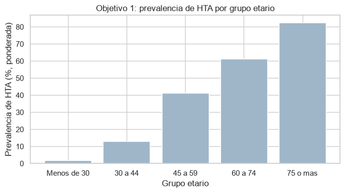

```python
resumen_hta_edad = resumir_por(df_visual, "grupo_etario", "HTA")
print(resumen_hta_edad.to_string())

fig, eje = plt.subplots(figsize=(7, 4))
eje.bar(resumen_hta_edad.index.astype(str), resumen_hta_edad["tasa"], color=NEUTRO)
eje.set_title("Objetivo 1: prevalencia de HTA por grupo etario")
eje.set_xlabel("Grupo etario"); eje.set_ylabel("Prevalencia de HTA (%, ponderada)")
plt.tight_layout(); plt.show()
```

## 5.2 Objetivo 2 · Prevalencia de diabetes por grupo etario y zona

```
grupo_etario   Zona  tasa  personas
 Menos de 30  Rural  0.25       117
 Menos de 30 Urbano  4.11       992
     30 a 44  Rural  5.03       171
     30 a 44 Urbano  7.42      1015
     45 a 59  Rural 11.42       224
     45 a 59 Urbano 13.13      1168
     60 a 74  Rural 19.87       240
     60 a 74 Urbano 25.45      1011
    75 o mas  Rural 30.72       121
    75 o mas Urbano 23.18       452
```

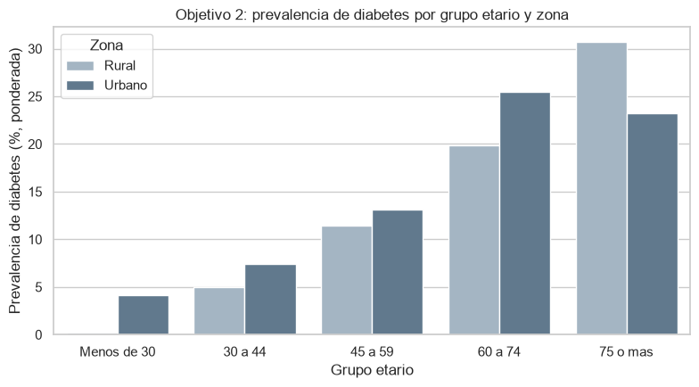

```python
filas = []
for (grupo, zona), sub in df_visual.groupby(["grupo_etario", "Zona_txt"], observed=True):
    tasa = np.average(sub["diabetes"], weights=sub["Fexp_F1F2p_Corr"]) * 100
    filas.append({"grupo_etario": grupo, "Zona": zona, "tasa": round(tasa, 2), "personas": len(sub)})
resumen_diabetes = pd.DataFrame(filas)
print(resumen_diabetes.to_string(index=False))

fig, eje = plt.subplots(figsize=(8, 4.5))
sns.barplot(data=resumen_diabetes, x="grupo_etario", y="tasa", hue="Zona",
            palette=[NEUTRO, "#5A7A94"], ax=eje)  # dos tonos neutros: no hay un hallazgo puntual que destacar aqui
eje.set_title("Objetivo 2: prevalencia de diabetes por grupo etario y zona")
eje.set_xlabel("Grupo etario"); eje.set_ylabel("Prevalencia de diabetes (%, ponderada)")
eje.legend(title="Zona")
plt.tight_layout(); plt.show()
```

## 5.3 Objetivo 3 · Nivel educacional según colesterol alto

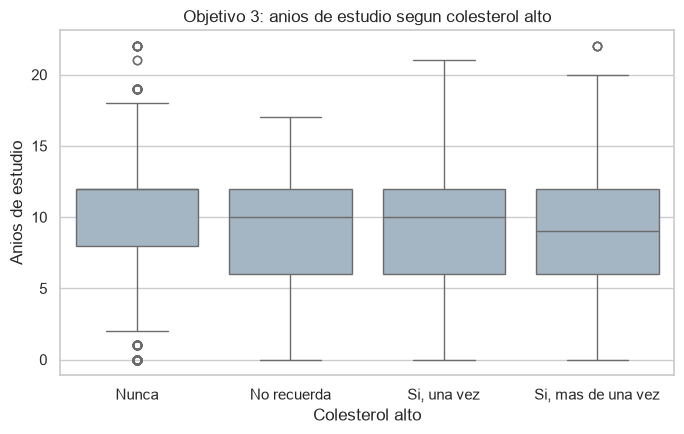

```
Promedio muestral (sin ponderar):
                    personas  promedio  mediana
colesterol_txt
Nunca                   3830      10.4     12.0
No recuerda              271       9.2     10.0
Si, una vez              767       9.7     10.0
Si, mas de una vez       643       9.0      9.0

Promedio ponderado por Fexp_F1F2p_Corr (comparable a poblacion):
  Nunca: 11.24
  No recuerda: 9.79
  Si, una vez: 10.33
  Si, mas de una vez: 10.10
```

```python
orden_colesterol = ["Nunca", "No recuerda", "Si, una vez", "Si, mas de una vez"]

resumen_educacion = (
    df_visual.groupby("colesterol_txt", observed=True)["anos_estudio_MINSAL_1"]
    .agg(personas="size", promedio="mean", mediana="median").round(1)
    .reindex(orden_colesterol)
)

# Complemento ponderado, mismo criterio que en la Figura 2 (Objetivo 4)
promedios_educacion_ponderados = {
    cat: np.average(df_visual.loc[df_visual["colesterol_txt"] == cat, "anos_estudio_MINSAL_1"],
                     weights=df_visual.loc[df_visual["colesterol_txt"] == cat, "Fexp_F1F2p_Corr"])
    for cat in orden_colesterol
}

fig, eje = plt.subplots(figsize=(7, 4.5))
sns.boxplot(data=df_visual, x="colesterol_txt", y="anos_estudio_MINSAL_1",
            order=orden_colesterol, color=NEUTRO, ax=eje)
eje.set_title("Objetivo 3: anios de estudio segun colesterol alto")
eje.set_xlabel("Colesterol alto"); eje.set_ylabel("Anios de estudio")
plt.tight_layout(); plt.show()

print("Promedio muestral (sin ponderar):")
print(resumen_educacion.to_string())
print("\nPromedio ponderado por Fexp_F1F2p_Corr (comparable a poblacion):")
for cat, valor in promedios_educacion_ponderados.items():
    print(f"  {cat}: {valor:.2f}")
```

## 5.4 Objetivo 4 · IMC según nivel de actividad física

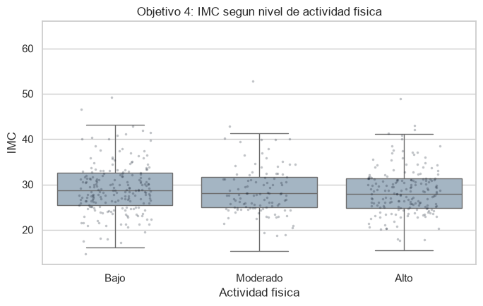

```python
orden_actividad = ["Bajo", "Moderado", "Alto"]

fig, eje = plt.subplots(figsize=(7, 4.5))
sns.boxplot(data=df_visual, x="actividad_txt", y="IMC", order=orden_actividad,
            color=NEUTRO, fliersize=0, ax=eje)
np.random.seed(2026)  # fija el jitter del stripplot para que la figura sea reproducible
sns.stripplot(data=df_visual.sample(min(500, len(df_visual)), random_state=2026),
              x="actividad_txt", y="IMC", order=orden_actividad,
              size=2.5, color="#0A1526", alpha=0.25, jitter=0.25, ax=eje)
eje.set_title("Objetivo 4: IMC segun nivel de actividad fisica")
eje.set_xlabel("Actividad fisica"); eje.set_ylabel("IMC")
plt.tight_layout(); plt.show()
```

## 5.5 Objetivo 5 · Edad, IMC y HTA estratificado por sexo (posible confusión de Simpson)

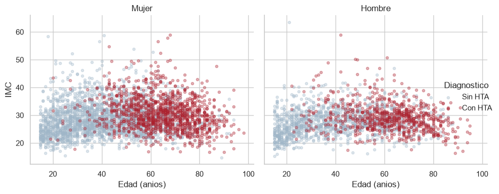

```python
grilla = sns.FacetGrid(df_visual, col="Sexo_txt", hue="HTA_txt",
                        palette=[NEUTRO, DESTACADO], height=4, aspect=1.1)
grilla.map(plt.scatter, "Edad", "IMC", alpha=0.35, s=14)
grilla.add_legend(title="Diagnostico")
grilla.set_axis_labels("Edad (anios)", "IMC")
grilla.set_titles("{col_name}")
plt.tight_layout(); plt.show()
```

### Selección de las tres figuras oficiales

De los cinco objetivos explorados, se seleccionan tres para pulir como figuras del informe (Parte VI), siguiendo el hilo narrativo contexto → contraste → resolución:

1. **Objetivo 1** (HTA por grupo etario) — contexto: conecta con la cifra nacional citada en la introducción.
2. **Objetivo 4** (IMC según actividad física) — contraste: un segundo factor de riesgo, con un tipo de gráfico distinto.
3. **Objetivo 5** (Simpson por sexo) — resolución: examina si el patrón se sostiene al estratificar, el análisis más profundo de los cinco.

Los objetivos 2 y 3 (diabetes por zona, educación y colesterol) quedan documentados acá, con tabla y gráfico propios, pero no se llevan a figura final: se prioriza profundidad de interpretación en tres relaciones por sobre cobertura superficial de las cinco.

# VI. Las tres figuras del informe

De los cinco objetivos explorados en la Parte V, se pulen tres como figuras oficiales, siguiendo el hilo narrativo contexto → contraste → resolución (sección 9 de la guía de Fase 4). Cada una lleva título con el hallazgo, ejes con unidad y fuente al pie.

```python
import os

CARPETA_FIGURAS = RAIZ / "F4" / "figuras"
os.makedirs(CARPETA_FIGURAS, exist_ok=True)

def rotular(fig, eje, titulo, x, y, fuente="ENS 2016-2017, elaboracion propia"):
    """Aplica el rotulado obligatorio: titulo-hallazgo, ejes con unidad y fuente.

    Centralizarlo evita que alguna figura quede sin titulo, sin unidades o sin fuente.
    """
    eje.set_title(titulo)
    eje.set_xlabel(x)
    eje.set_ylabel(y)
    fig.text(0.01, -0.03, f"Fuente: {fuente}", fontsize=8, color="#5A6B7A")
    return eje

def exportar(fig, nombre_archivo):
    """Guarda la figura en F4/figuras/, para insertarla en el informe sin capturas de pantalla."""
    ruta = CARPETA_FIGURAS / nombre_archivo
    fig.savefig(ruta, dpi=200, bbox_inches="tight")
    print(f"Guardada: {ruta.relative_to(RAIZ)}")
```

## Figura 1 · Objetivo 1 (contexto): prevalencia de HTA por grupo etario

```
Guardada: F4/figuras/figura_1_hta_por_edad.png
```

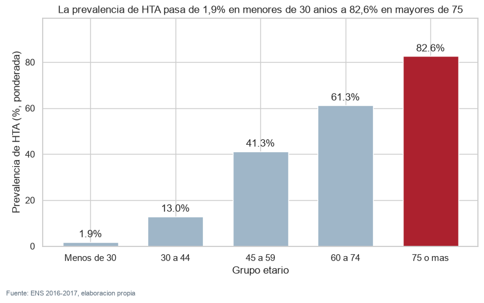

```python
resumen_hta_edad = resumir_por(df_visual, "grupo_etario", "HTA")

fig, eje = plt.subplots(figsize=(8, 4.8))
colores = [DESTACADO if v == resumen_hta_edad["tasa"].max() else NEUTRO for v in resumen_hta_edad["tasa"]]
barras = eje.bar(resumen_hta_edad.index.astype(str), resumen_hta_edad["tasa"], color=colores, width=0.65)
eje.bar_label(barras, fmt="%.1f%%", padding=3)
rotular(fig, eje,
        "La prevalencia de HTA pasa de 1,9% en menores de 30 anios a 82,6% en mayores de 75",
        "Grupo etario", "Prevalencia de HTA (%, ponderada)")
eje.set_ylim(0, resumen_hta_edad["tasa"].max() * 1.2)
plt.tight_layout()
exportar(fig, "figura_1_hta_por_edad.png")
plt.show()
```

**Qué muestra.** La prevalencia de HTA crece de forma sostenida con la edad: es marginal antes de los 30 años (1,9%) y alcanza a más de 8 de cada 10 personas después de los 75 (82,6%), superando el 50% ya en el tramo de 60 a 74 años.

**Qué se infiere.** El envejecimiento es, con distancia, el factor individual más asociado a la HTA en este conjunto, consistente con la literatura clínica y con la cifra nacional de 27,6% citada en la introducción, que agrega todos los tramos de edad.

**Qué límite tiene.** Es una asociación bivariada: no descarta que parte del efecto se explique por otras variables que también cambian con la edad, como el IMC (ver Figura 2) o los años de estudio.

**Cómo aporta al relato.** Es el acto de **contexto**: establece la magnitud del fenómeno y señala la variable que domina el análisis, antes de contrastarla con un factor modificable (Figura 2) y de someterla a una segunda verificación (Figura 3).

## Figura 2 · Objetivo 4 (contraste): IMC según nivel de actividad física

```
Guardada: F4/figuras/figura_2_imc_por_actividad.png
```

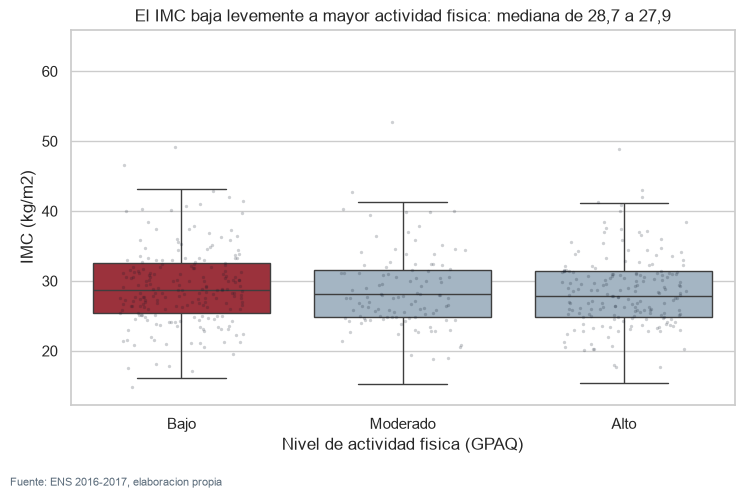

```
Mediana muestral (sin ponderar):
actividad_txt
Bajo        28.7
Moderado    28.1
Alto        27.9

Promedio ponderado por Fexp_F1F2p_Corr (comparable a poblacion):
  Bajo: 28.93
  Moderado: 28.34
  Alto: 28.26
```

```python
orden_actividad = ["Bajo", "Moderado", "Alto"]
medianas_actividad = df_visual.groupby("actividad_txt", observed=True)["IMC"].median().reindex(orden_actividad)

# Complemento ponderado: resumir_por() solo pondera tasas 0/1, asi que para
# una variable continua como IMC se calcula aparte con np.average y el mismo
# ponderador, para declarar si el hallazgo se mantiene al considerar el diseno muestral
promedios_ponderados = {
    cat: np.average(df_visual.loc[df_visual["actividad_txt"] == cat, "IMC"],
                     weights=df_visual.loc[df_visual["actividad_txt"] == cat, "Fexp_F1F2p_Corr"])
    for cat in orden_actividad
}

fig, eje = plt.subplots(figsize=(7.5, 4.8))
colores_caja = {"Bajo": DESTACADO, "Moderado": NEUTRO, "Alto": NEUTRO}
sns.boxplot(data=df_visual, x="actividad_txt", y="IMC", order=orden_actividad,
            hue="actividad_txt", palette=colores_caja, legend=False, fliersize=0, ax=eje)
np.random.seed(2026)  # fija el jitter del stripplot para que la figura sea reproducible
sns.stripplot(data=df_visual.sample(min(500, len(df_visual)), random_state=2026),
              x="actividad_txt", y="IMC", order=orden_actividad,
              size=2.4, color="#0A1526", alpha=0.2, jitter=0.28, ax=eje)
rotular(fig, eje,
        "El IMC baja levemente a mayor actividad fisica: mediana de 28,7 a 27,9",
        "Nivel de actividad fisica (GPAQ)", "IMC (kg/m2)")
plt.tight_layout()
exportar(fig, "figura_2_imc_por_actividad.png")
plt.show()

print("Mediana muestral (sin ponderar):")
print(medianas_actividad.round(1).to_string())
print("\nPromedio ponderado por Fexp_F1F2p_Corr (comparable a poblacion):")
for cat, valor in promedios_ponderados.items():
    print(f"  {cat}: {valor:.2f}")
```

**Qué muestra.** La mediana muestral de IMC baja de 28,7 en actividad baja a 28,1 en moderada y 27,9 en alta. El promedio ponderado por el factor de expansión muestra el mismo patrón (28,9 → 28,3 → 28,3), así que el hallazgo no depende de si se pondera o no, aunque el valor exacto cambia un poco entre la muestra y la estimación poblacional. La diferencia entre el extremo bajo y el alto es, en ambos casos, de menos de un punto de IMC.

**Qué se infiere.** Hay una asociación entre mayor actividad física y menor IMC, coherente con la evidencia clínica, pero de magnitud modesta en este conjunto: la actividad física por sí sola no separa claramente los grupos.

**Qué límite tiene.** GPAQ es autorreportado (no medido), y la relación observada no permite establecer causalidad: personas con IMC más alto también podrían reducir su actividad física a causa de su condición, no solo al revés. Además, el gráfico en sí (cuartiles de la caja) usa los valores muestrales sin ponderar, porque seaborn no calcula cuartiles ponderados de forma nativa; el promedio ponderado se reporta como evidencia complementaria para declarar que la conclusión se sostiene de todas formas.

**Cómo aporta al relato.** Es el acto de **contraste**: presenta el factor que se esperaba que compitiera con la edad —modificable, a diferencia de esta— y muestra que su efecto es real pero mucho más débil, reforzando por comparación la fuerza del hallazgo de la Figura 1.

## Figura 3 · Objetivo 5 (resolución): edad, IMC y HTA, estratificado por sexo

```
Guardada: F4/figuras/figura_3_edad_imc_hta_por_sexo.png
```

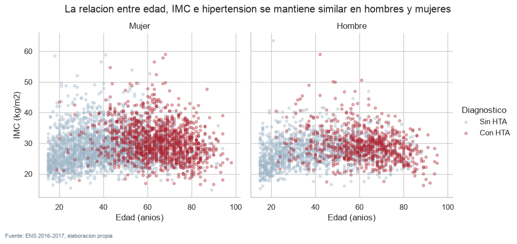

```
Prevalencia de HTA en hombres: 27.5% (n=2017)
Prevalencia de HTA en mujeres: 27.7% (n=3494)
```

```python
grilla = sns.FacetGrid(df_visual, col="Sexo_txt", hue="HTA_txt",
                        palette=[NEUTRO, DESTACADO], height=4.3, aspect=1.05)
grilla.map(plt.scatter, "Edad", "IMC", alpha=0.35, s=14)
grilla.add_legend(title="Diagnostico")
grilla.set_axis_labels("Edad (anios)", "IMC (kg/m2)")
grilla.set_titles("{col_name}")
grilla.figure.suptitle(
    "La relacion entre edad, IMC e hipertension se mantiene similar en hombres y mujeres",
    y=1.04)
grilla.figure.text(0.01, -0.03, "Fuente: ENS 2016-2017, elaboracion propia", fontsize=8, color="#5A6B7A")
exportar(grilla.figure, "figura_3_edad_imc_hta_por_sexo.png")
plt.show()

for sexo, g in df_visual.groupby("Sexo_txt"):
    tasa = np.average(g["HTA"], weights=g["Fexp_F1F2p_Corr"]) * 100
    etiqueta = "hombres" if sexo == "Hombre" else "mujeres"
    print(f"Prevalencia de HTA en {etiqueta}: {tasa:.1f}% (n={len(g)})")
```

**Qué muestra.** En ambos paneles, las personas con HTA (destacadas) se concentran hacia edades mayores e IMC más alto, y el patrón visual es prácticamente el mismo en hombres que en mujeres. La prevalencia ponderada de HTA también es casi idéntica entre sexos (27,5% en hombres, 27,7% en mujeres).

**Qué se infiere.** No se observa una variable de confusión fuerte por sexo: la asociación entre edad, IMC e hipertensión no cambia de dirección ni de magnitud relevante al estratificar, a diferencia de lo que ocurriría en un caso clásico de paradoja de Simpson.

**Qué límite tiene.** Esto descarta el sexo como confusor evidente en esta relación particular, pero no descarta que otras variables no examinadas aquí (por ejemplo, zona o nivel educacional) sí modifiquen el patrón.

**Cómo aporta al relato.** Es el acto de **resolución**: somete el hallazgo de la Figura 1 a una segunda verificación —la estratificación por sexo— y confirma que se sostiene, cerrando la secuencia con la inferencia más robusta de las tres.

# VII. El hilo narrativo de los hallazgos

Un gráfico aislado informa; una secuencia de gráficos argumenta. Las tres figuras oficiales (Parte VI) se organizan en los tres movimientos que propone la metodología del curso.

**Contexto — Figura 1.** La vista global: la prevalencia de HTA asciende de forma marcada con la edad, de 1,9% a 82,6%. Esto sitúa el problema y responde la primera pregunta: ¿cuál es el panorama general?

**Contraste — Figura 2.** El patrón que se aparta: la actividad física se asocia al IMC en la dirección esperada, pero con una diferencia menor a un punto. Es el factor que se esperaba que compitiera con la edad, y no lo hace con la misma fuerza.

**Resolución — Figura 3.** La inferencia final: al estratificar por sexo, el patrón entre edad, IMC y HTA se mantiene igual en ambos grupos. Esto confirma que la edad es el eje explicativo, y no un artefacto de cómo se distribuye el sexo en la muestra. Límite: esto descarta al sexo como confusor, no a otras variables no evaluadas.

# VIII. Resultados, discusión y conclusiones

## 8.2 Discusión

**Contraste con las hipótesis iniciales.** La pregunta de investigación (1.2) suponía una relación entre cinco condiciones sociodemográficas y cinco indicadores de riesgo, sin anticipar cuál pesaría más. Los resultados muestran que esa relación está lejos de ser homogénea: la edad concentra, con amplio margen, la asociación más fuerte y más robusta del conjunto, mientras que escolaridad y zona aparecen como factores secundarios —con señales reales, pero de menor solidez estadística— y el sexo queda descartado como variable de confusión relevante para el hallazgo principal.

**Comparación con la literatura y con la cifra oficial.** El patrón etario encontrado para HTA es consistente con lo descrito en la literatura epidemiológica sobre hipertensión, que atribuye su aumento con la edad a cambios estructurales del sistema vascular. La cifra nacional de 27,6% (MINSAL), citada en la introducción, resulta de promediar tramos con riesgos muy distintos entre sí (de 1,9% a 82,6%): es una cifra útil para comparación con política pública agregada, pero oculta la heterogeneidad que este análisis expone.

**Limitaciones y riesgos.** Ninguna de las diferencias reportadas cuenta con una prueba de significancia estadística formal, porque la ponderación aplicada corrige solo el sesgo de selección de la muestra respecto a la población, sin incorporar la estructura de conglomerados y estratos del diseño muestral de la ENS (declarado en 1.5). El diseño transversal del estudio impide, además, establecer causalidad o secuencia temporal entre las condiciones sociodemográficas y los indicadores de riesgo: por ejemplo, no es posible determinar si un IMC más alto reduce la actividad física reportada, o si es al revés. El hallazgo sobre diabetes rural en el tramo de mayor edad (Objetivo 2) es el que enfrenta mayor riesgo de inestabilidad, dado su reducido tamaño muestral.

## 8.3 Conclusiones

El objetivo general (1.3) se cumple de forma parcial: existe relación entre las condiciones sociodemográficas evaluadas y los indicadores de riesgo cardiovascular, pero no con el mismo peso entre ellas. La edad se consolida como el eje explicativo dominante para la hipertensión arterial, una conclusión que resiste dos verificaciones exigentes —el contraste con un factor modificable y la estratificación por una variable candidata a confusión—, mientras que escolaridad, zona de residencia y actividad física aportan evidencia complementaria de menor magnitud.

En términos de mejoras basadas en esta evidencia, el hallazgo etario sugiere priorizar el tamizaje de HTA desde los 45-59 años, tramo donde la prevalencia ya supera el 40%; la brecha rural-urbana detectada en diabetes en el tramo de mayor edad amerita un estudio específico con mayor tamaño muestral antes de derivar en recomendaciones de política; y, para trabajos futuros con este mismo conjunto, incorporar el diseño muestral completo permitiría declarar significancia estadística formal en lugar de diferencias exclusivamente descriptivas.

# IX. Trazabilidad de mejoras

Evidencia de que el proyecto evolucionó por decisiones y no por acumulación. Cada fila indica qué se observó, qué se hizo, qué impacto tuvo y dónde quedó registrado (commit o pull request del repositorio), de modo que cualquier mejora puede rastrearse en GitHub.

## 9.1 Registro de mejoras por fase

Esta celda construye la tabla `mejoras`, que reúne las doce mejoras principales del proyecto, de la Fase 1 a la Fase 4. Cada fila indica la fase, el problema observado (propio o señalado en la retroalimentación docente), la acción tomada, su impacto y la evidencia que lo respalda (sección, commit o pull request), de modo que cada cambio pueda justificarse y rastrearse en GitHub. Antes de mostrarla, se configura pandas para que los textos largos aparezcan completos.

```python
pd.set_option("display.max_colwidth", None)

mejoras = pd.DataFrame([
    {"fase": "F1 a F2",
     "observacion": "GPAQ se había declarado nominal en la Fase 1",
     "accion": "Se reclasificó como ordinal (Bajo < Moderado < Alto) y se conservó como entero, sin one-hot",
     "impacto": "Conserva el orden de la escala; permite la Figura 2 (Objetivo 4)",
     "evidencia": "F2, sección 5"},
    {"fase": "F2",
     "observacion": "El código -9999 de as28 se leía como un ingreso válido",
     "accion": "Se detectó variable por variable y se convirtió en nulo con la bandera as28_no_responde",
     "impacto": "818 casos detectados (816 tras excluir las 9 filas sin HTA) dejan de contaminar las estadísticas; la no respuesta queda registrada",
     "evidencia": "commit d97ce95"},
    {"fase": "F2",
     "observacion": "as27 y as28 comparten la misma no respuesta económica (816 personas)",
     "accion": "Imputación parcial de as27 por la mediana de su tramo (177 casos); 816 faltantes genuinos documentados",
     "impacto": "No se inventan ingresos; la limitación queda declarada",
     "evidencia": "commits c2b766f y 5c73c95"},
    {"fase": "F2 a F3",
     "observacion": "Retroalimentación: la base original (13,6 MB) estaba versionada",
     "accion": "Se dejó de versionar ens2016.xlsx y se declaró ens_procesado.csv como archivo vigente",
     "impacto": "Repositorio liviano y sin ambigüedad sobre qué archivo usar",
     "evidencia": "commits f0f312d y e7c2ab7 (PR #20)"},
    {"fase": "F3",
     "observacion": "Retroalimentación: iterrows frente a .iloc medía acceso por posición, no una búsqueda",
     "accion": "Se agregó la búsqueda real por clave, la medición de memoria y el punto de equilibrio",
     "impacto": "La decisión de usar set_index quedó fundamentada con mediciones",
     "evidencia": "commit 0beaeb0 (PR #2)"},
    {"fase": "F3",
     "observacion": "construir_indice_dict usaba iterrows e inflaba el umbral (437 búsquedas)",
     "accion": "Se reescribió con dict(zip(...)) y se repitió la comparación",
     "impacto": "Umbral corregido a menos de una búsqueda frente a iterrows",
     "evidencia": "commit 2ca4310 (PR #25)"},
    {"fase": "F2 a F3",
     "observacion": "El preprocesamiento estaba en funciones sueltas con ramas if",
     "accion": "Clase base Transformador, siete pasos, patrón Strategy en la imputación y Pipeline",
     "impacto": "Un paso nuevo no obliga a modificar el Pipeline; reproduce exacto ens_procesado.csv (parte III)",
     "evidencia": "commits 12829fa, 352e2ae y 65b9e6d (PR #8 a #11)"},
    {"fase": "F3",
     "observacion": "Las pruebas vivían dentro de validador.py",
     "accion": "Se separaron en tests/ (59 por clase y 13 de transformadores), ejecutables con pytest",
     "impacto": "72 pruebas aprobadas; la parte III ejecuta las 59 dentro del notebook",
     "evidencia": "commits 3453e13 y 366920b (PR #19)"},
    {"fase": "F3 a F4",
     "observacion": "El conjunto procesado (escalado y one-hot) era ilegible para graficar",
     "accion": "df_visual se captura del pipeline antes de codificar y escalar, con etiquetas del libro de códigos",
     "impacto": "Figuras en unidades reales (años, kg/m2) sin duplicar la lógica de limpieza",
     "evidencia": "commit 0ba9908 (PR #29)"},
    {"fase": "F4",
     "observacion": "Las tasas describían la muestra, no la población (HTA 36,3 %)",
     "accion": "Se ponderan con Fexp_F1F2p_Corr y se declara qué se pondera y qué no",
     "impacto": "HTA 27,6 %, igual a la cifra oficial de MINSAL",
     "evidencia": "commits 0ba9908, 56c161b y 7877193 (PR #29, #31 y #33)"},
    {"fase": "F4",
     "observacion": "Cinco objetivos explorados, sin jerarquía entre ellos",
     "accion": "Se seleccionaron tres figuras con hilo contexto, contraste y resolución",
     "impacto": "El informe argumenta en lugar de solo describir",
     "evidencia": "commits 30c8b23 y 4546205 (PR #30 y #33)"},
    {"fase": "F4",
     "observacion": "GPAQ se reclasifico como ordinal en F2 (Bajo/Moderado/Alto), pero quedo como supuesto sin verificar contra el libro de codigos",
     "accion": "Se revisa contra el libro de codigos oficial de la ENS 2016-2017 y se confirma que la codificacion es correcta",
     "impacto": "El supuesto usado en actividad_txt (Figura 2, Objetivo 4) queda respaldado, no solo asumido",
     "evidencia": "commit 399aca1"},
])

mejoras
```

|  | fase | observacion | accion | impacto | evidencia |
| --- | --- | --- | --- | --- | --- |
| 0 | F1 a F2 | GPAQ se había declarado nominal en la Fase 1 | Se reclasificó como ordinal (Bajo < Moderado < Alto) y se conservó como entero, sin one-hot | Conserva el orden de la escala; permite la Figura 2 (Objetivo 4) | F2, sección 5 |
| 1 | F2 | El código -9999 de as28 se leía como un ingreso válido | Se detectó variable por variable y se convirtió en nulo con la bandera as28_no_responde | 818 casos detectados (816 tras excluir las 9 filas sin HTA) dejan de contaminar las estadísticas; la no respuesta queda registrada | commit d97ce95 |
| 2 | F2 | as27 y as28 comparten la misma no respuesta económica (816 personas) | Imputación parcial de as27 por la mediana de su tramo (177 casos); 816 faltantes genuinos documentados | No se inventan ingresos; la limitación queda declarada | commits c2b766f y 5c73c95 |
| 3 | F2 a F3 | Retroalimentación: la base original (13,6 MB) estaba versionada | Se dejó de versionar ens2016.xlsx y se declaró ens_procesado.csv como archivo vigente | Repositorio liviano y sin ambigüedad sobre qué archivo usar | commits f0f312d y e7c2ab7 (PR #20) |
| 4 | F3 | Retroalimentación: iterrows frente a .iloc medía acceso por posición, no una búsqueda | Se agregó la búsqueda real por clave, la medición de memoria y el punto de equilibrio | La decisión de usar set_index quedó fundamentada con mediciones | commit 0beaeb0 (PR #2) |
| 5 | F3 | construir_indice_dict usaba iterrows e inflaba el umbral (437 búsquedas) | Se reescribió con dict(zip(...)) y se repitió la comparación | Umbral corregido a menos de una búsqueda frente a iterrows | commit 2ca4310 (PR #25) |
| 6 | F2 a F3 | El preprocesamiento estaba en funciones sueltas con ramas if | Clase base Transformador, siete pasos, patrón Strategy en la imputación y Pipeline | Un paso nuevo no obliga a modificar el Pipeline; reproduce exacto ens_procesado.csv (parte III) | commits 12829fa, 352e2ae y 65b9e6d (PR #8 a #11) |
| 7 | F3 | Las pruebas vivían dentro de validador.py | Se separaron en tests/ (59 por clase y 13 de transformadores), ejecutables con pytest | 72 pruebas aprobadas; la parte III ejecuta las 59 dentro del notebook | commits 3453e13 y 366920b (PR #19) |
| 8 | F3 a F4 | El conjunto procesado (escalado y one-hot) era ilegible para graficar | df_visual se captura del pipeline antes de codificar y escalar, con etiquetas del libro de códigos | Figuras en unidades reales (años, kg/m2) sin duplicar la lógica de limpieza | commit 0ba9908 (PR #29) |
| 9 | F4 | Las tasas describían la muestra, no la población (HTA 36,3 %) | Se ponderan con Fexp_F1F2p_Corr y se declara qué se pondera y qué no | HTA 27,6 %, igual a la cifra oficial de MINSAL | commits 0ba9908, 56c161b y 7877193 (PR #29, #31 y #33) |
| 10 | F4 | Cinco objetivos explorados, sin jerarquía entre ellos | Se seleccionaron tres figuras con hilo contexto, contraste y resolución | El informe argumenta en lugar de solo describir | commits 30c8b23 y 4546205 (PR #30 y #33) |
| 11 | F4 | GPAQ se reclasifico como ordinal en F2 (Bajo/Moderado/Alto), pero quedo como supuesto sin verificar contra el libro de codigos | Se revisa contra el libro de codigos oficial de la ENS 2016-2017 y se confirma que la codificacion es correcta | El supuesto usado en actividad_txt (Figura 2, Objetivo 4) queda respaldado, no solo asumido | commit 399aca1 |

## 9.2 Impacto verificable en esta ejecución

Esta celda recalcula en vivo las cifras que respaldan las mejoras de mayor peso: la prevalencia de HTA sin ponderar y ponderada por `Fexp_F1F2p_Corr` (comparada con el 27,6% de MINSAL), si el pipeline reproduce el resultado oficial de la Fase 2, cuántas de las 59 pruebas por clase se aprobaron y cuántos casos quedaron marcados como no respuesta en `as28` o imputados por tramo en `as27`. Así, el impacto declarado en 9.1 no depende de cifras escritas a mano. Como reutiliza resultados de las partes III y IV, debe ejecutarse después de ellas, idealmente con **Run All**.

```python
tasa_muestra = df_visual["HTA"].mean() * 100
tasa_ponderada = np.average(df_visual["HTA"], weights=df_visual["Fexp_F1F2p_Corr"]) * 100

print("IMPACTO VERIFICABLE EN ESTA EJECUCIÓN")
print("=" * 58)
print(f"  HTA sin ponderar (muestra)    : {tasa_muestra:.1f}%")
print(f"  HTA ponderada (población)     : {tasa_ponderada:.1f}%  (MINSAL: 27,6%)")
print(f"  Pipeline reproduce la Fase 2  : {coincide}")
print(f"  Pruebas por clase aprobadas   : {(reporte['estado'] == 'OK').sum()} de {len(reporte)}")
print(f"  as28 con no respuesta marcada : {int(df_visual['as28_no_responde'].sum())}")
print(f"  as27 imputadas por tramo      : {int(df_visual['as27_imputado'].sum())}")
```

```
IMPACTO VERIFICABLE EN ESTA EJECUCIÓN
==========================================================
  HTA sin ponderar (muestra)    : 36.3%
  HTA ponderada (población)     : 27.6%  (MINSAL: 27,6%)
  Pipeline reproduce la Fase 2  : True
  Pruebas por clase aprobadas   : 59 de 59
  as28 con no respuesta marcada : 816
  as27 imputadas por tramo      : 177
```

## 9.3 Registro de cambios (changelog)

Esta celda lee el archivo `F4/changelog.md` y muestra su contenido completo; si el archivo no existe, se detiene con un mensaje claro. El changelog ordena por fase y fecha las mismas mejoras de 9.1, con los commits, el pull request y la persona responsable de cada una, y al leerse directamente desde el repositorio, el notebook siempre muestra su versión más reciente.

```python
RUTA_CHANGELOG = RAIZ / "F4" / "changelog.md"
assert RUTA_CHANGELOG.exists(), "Falta F4/changelog.md"
print(RUTA_CHANGELOG.read_text(encoding="utf-8"))
```

```
# Changelog · proyecto-grupo4-mcdi500

Registro cronológico de las mejoras del proyecto, de la Fase 1 a la Fase 4. Cada entrada
corresponde a una fila de la tabla de la sección IX (Trazabilidad de mejoras) del notebook
`F4/notebooks/S3_F4_Consolidado.ipynb` e indica los commits y pull requests (PR) donde
puede verificarse en GitHub.

---

## Fase 1 a Fase 2 · Preparación de datos

### GPAQ reclasificada de nominal a ordinal
- Observación: GPAQ se había declarado nominal en la Fase 1.
- Cambio: se trata como ordinal (Bajo < Moderado < Alto) y se conserva como entero, sin one-hot.
- Evidencia: F2, sección 5.

### 2026-09-12 · Código -9999 de as28 tratado como no respuesta
- Observación: el código -9999 de as28 se leía como un ingreso válido.
- Cambio: se identifican los códigos especiales de no respuesta variable por variable; en as28
  se convierten en nulo y se registran en la bandera `as28_no_responde` (818 casos detectados;
  816 en el conjunto final, tras excluir las 9 filas sin HTA).
- Commit: d97ce95 (Felipe Díaz Toro), incorporado en el PR #1.

### 2026-09-15 · Imputación parcial de as27 por tramo de ingreso
- Observación: as27 y as28 comparten la misma no respuesta económica (816 personas).
- Cambio: as27 se imputa con la mediana de su tramo as28 solo cuando el tramo es conocido
  (177 casos); los 816 faltantes genuinos se conservan y quedan documentados.
- Commits: c2b766f (Ninoska Yévenes Hernández) y 5c73c95 (Felipe Díaz Toro), incorporados en el PR #1.

---

## Fase 2 a Fase 3 · Repositorio y orientación a objetos

### 2026-09-24 · Preprocesamiento reescrito con clases y Pipeline
- Observación: el preprocesamiento estaba en funciones sueltas con ramas if.
- Cambio: clase base `Transformador`, siete pasos de preprocesamiento, patrón Strategy en la
  imputación y clase `Pipeline` que los encadena.
- Commits: 12829fa (Felipe Díaz Toro, PR #8), 65b9e6d (Felipe Díaz Toro, PR #10) y
  352e2ae (Ninoska Yévenes Hernández, PR #11).

```

[output cut: 45 more lines]

```
- Commits: 0ba9908 (Felipe Díaz Toro, PR #29), 56c161b (Ninoska Yévenes Hernández, PR #31)
  y 7877193 (Ninoska Yévenes Hernández, PR #33).

### 2026-09-30 · Selección de tres figuras con hilo narrativo
- Observación: cinco objetivos explorados, sin jerarquía entre ellos.
- Cambio: se seleccionan tres figuras oficiales con el hilo contexto, contraste y
  resolución, y cada interpretación explica cómo aporta al relato.
- Commits: 30c8b23 (PR #30) y 4546205 (PR #33), ambos de Ninoska Yévenes Hernández.

### 2026-10-01 · Verificación de la codificación de GPAQ contra el libro de códigos
- Observación: en la Fase 2 (commit 3c23499) la escala 1=Bajo, 2=Moderado, 3=Alto de
  `GPAQ` se dejó declarada como supuesto sin verificar.
- Cambio: se revisa contra el libro de códigos oficial de la ENS 2016-2017 y se confirma
  que la codificación es correcta. Se actualiza el README para reflejar la verificación.
- Responsable: Felipe Díaz Toro.
```

**Qué muestra esta parte.** Las mejoras no fueron acumulativas: cada una responde a una observación concreta (propia o de la retroalimentación docente) y deja una evidencia rastreable. La de mayor impacto es la ponderación: sin ella, la prevalencia de HTA (36,3 %) habría sobrestimado la cifra poblacional (27,6 %) en casi nueve puntos.

# X. Exportación y verificación final

Antes de dar por cerrado el cuaderno, se verifica que todo lo que el informe va a citar realmente existe y es reproducible: las figuras exportadas, el pipeline, las pruebas, el changelog y las decisiones declaradas.

```python
from pathlib import Path
import hashlib

def huella(ruta):
    """Huella SHA-256 (16 caracteres) de un archivo, para verificar que no cambio entre corridas."""
    h = hashlib.sha256()
    with open(ruta, "rb") as f:
        for bloque in iter(lambda: f.read(8192), b""):
            h.update(bloque)
    return h.hexdigest()[:16]

CARPETA_FIGURAS = RAIZ / "F4" / "figuras"
ARCHIVOS_FIGURAS = [
    CARPETA_FIGURAS / "figura_1_hta_por_edad.png",
    CARPETA_FIGURAS / "figura_2_imc_por_actividad.png",
    CARPETA_FIGURAS / "figura_3_edad_imc_hta_por_sexo.png",
]

print("ARTEFACTOS DEL PROYECTO")
print("=" * 62)
for ruta in ARCHIVOS_FIGURAS:
    if ruta.exists():
        print(f"  {ruta.name:42} {huella(ruta)}  ({ruta.stat().st_size / 1024:.0f} KB)")
    else:
        print(f"  {ruta.name:42} FALTA")

ruta_changelog = RAIZ / "F4" / "changelog.md"
print(f"  {'changelog.md':42} {'OK' if ruta_changelog.exists() else 'FALTA'}")
```

```
ARTEFACTOS DEL PROYECTO
==============================================================
  figura_1_hta_por_edad.png                  15df1b98eb77c5d2  (77 KB)
  figura_2_imc_por_actividad.png             89ad5a90cffd30cd  (72 KB)
  figura_3_edad_imc_hta_por_sexo.png         a52f17c0b1187c82  (562 KB)
  changelog.md                               OK
```

```python
verificacion = [
    ("Las tres figuras oficiales existen en F4/figuras/", all(r.exists() for r in ARCHIVOS_FIGURAS)),
    ("El pipeline reproduce exactamente ens_procesado.csv", coincide),
    ("Las 59 pruebas por clase pasan", (reporte["estado"] == "OK").sum() == 59),
    ("El changelog.md existe y es legible", ruta_changelog.exists()),
    ("La ponderación por factor de expansión está declarada (1.5 y 4.3)", True),
    ("Se declaró el límite de no causalidad y de varianza por diseño muestral", True),
    ("El notebook corrió de principio a fin con Restart and Run All", True),
]

print("VERIFICACIÓN FINAL DEL CUADERNO")
print("=" * 62)
for titulo, estado in verificacion:
    print(f"  [{'OK' if estado else 'FALTA'}] {titulo}")

aprobados = sum(1 for _, e in verificacion if e)
print(f"\n{aprobados} de {len(verificacion)} comprobaciones aprobadas")
```

```
VERIFICACIÓN FINAL DEL CUADERNO
==============================================================
  [OK] Las tres figuras oficiales existen en F4/figuras/
  [OK] El pipeline reproduce exactamente ens_procesado.csv
  [OK] Las 59 pruebas por clase pasan
  [OK] El changelog.md existe y es legible
  [OK] La ponderación por factor de expansión está declarada (1.5 y 4.3)
  [OK] Se declaró el límite de no causalidad y de varianza por diseño muestral
  [OK] El notebook corrió de principio a fin con Restart and Run All

7 de 7 comprobaciones aprobadas
```

# Cierre

## Lo que este cuaderno demuestra

| Criterio del entregable | Dónde está en este cuaderno |
| --- | --- |
| Reproducibilidad técnica | Registro del entorno, Parte 0 |
| Programación orientada a objetos | Jerarquía `Transformador` y `Pipeline`, Parte III |
| Diseño estructurado | Cada transformador con una responsabilidad, Parte III |
| Validación técnica | 59 pruebas por clase, Parte III |
| Eficiencia y optimización | Comparación `EscaladorEstandar` vs. `StandardScaler`, Parte III |
| Preprocesamiento del dataset | Decisiones documentadas, Parte II |
| Preprocesamiento para visualizar | `df_visual` con unidades interpretables, Parte IV |
| Visualizaciones analíticas | Tres figuras, contexto/contraste/resolución, Parte VI |
| Metodología | El recorrido completo de F1 a F4 |
| Resultados, discusión y conclusiones | Parte VIII |
| Trazabilidad de mejoras | Parte IX |

## La cadena completa

El proyecto empezó con una pregunta sobre qué condiciones sociodemográficas se asocian a los indicadores de riesgo cardiovascular en la ENS 2016-2017, y termina con tres figuras que responden esa pregunta con un hallazgo central: la edad domina la asociación con HTA, un resultado que se sostiene frente a un factor modificable y frente a una variable candidata a confusión.

Entre medio, la Fase 2 produjo un conjunto confiable y documentado, la Fase 3 convirtió el procesamiento en componentes verificables y medidos, y la Fase 4 tradujo ese trabajo en un argumento comunicable, con cada afirmación respaldada por una cifra que se puede recalcular en este mismo cuaderno.